# Murder and assault in the US

Sebastian Martinez

October 3, 2015

## Background information

This presentation shows a complementary analysis of crime and the judicial system in the United States of America. The document available in [this document](https://github.com/fabianbohnenberger/repo1/blob/master/analysis/USJudges/USJudges_RMarkdown.pdf) shows the rating of US Supreme Court Justices.

The analysis coming up complements the previous one by the showing the number of arrests for the crimes of murder and assault per 100,000 residents in all States of the country. Further information on the dataset can be found [here](https://stat.ethz.ch/R-manual/R-devel/library/datasets/html/USArrests.html). Also included in the information is the percentage of the population that lives in urban areas.

## An overview of Murder rates

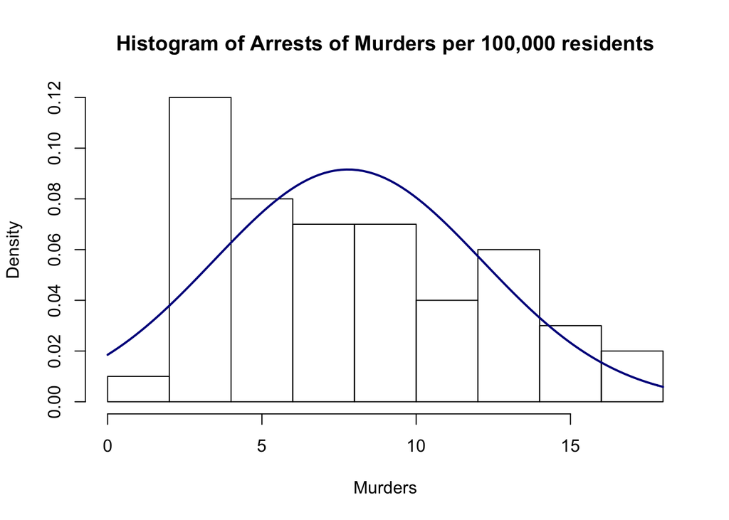

```r
mydata <- USArrests
Murders <- USArrests$Murder
hist(Murders, freq=FALSE, main = "Histogram of Arrests of Murders per 100,000 residents")
curve(dnorm(x, mean=mean(Murders), sd=sd(Murders)), add=TRUE, col="darkblue", lwd=2)
```

This histogram shows the density distribution of murder rates in the US. As reference, the graph for a normal distribution function is added to show the difference between the two. Similarly, a histogram with the distribution of arrests for assaults per 100,000 residents is show up next. Note how the distribution seems to be closer to the *normal* distribution in comparison. A more in-depth analysis might be needed to check whether this two variables actually behave like draws from a normal distribution with their respective means and standard deviations.

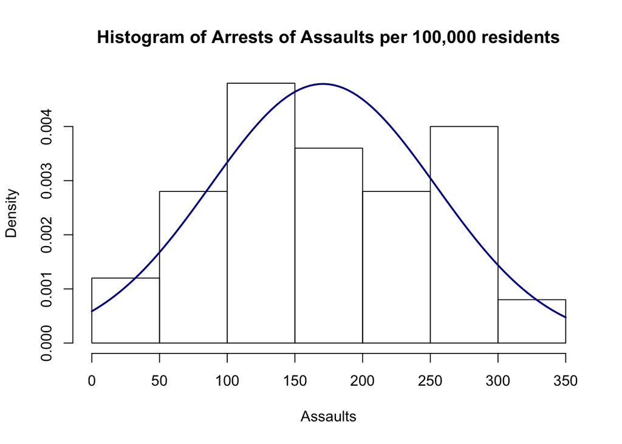

```r
Assaults <- USArrests$Assault
hist(Assaults, freq=FALSE, main = "Histogram of Arrests of Assaults per 100,000 residents")
curve(dnorm(x, mean=mean(Assaults), sd=sd(Assaults)), add=TRUE, col="darkblue", lwd=2)
```

More precise information is included in the following table:

| Variable | range | mean | median | standard deviation |
| --- | --- | --- | --- | --- |
| *Murders* | 0.8, 17.4 | 7.788 | 7.25 | 4.3555098 |
| *Assaults* | 45, 337 | 170.76 | 159 | 83.3376608 |

To continue testing whether the arrests for murders and assaults follow a normal distribution, a qq-plot is added to the analysis. This technique plots the quantiles of both the hypothetical distribution and the real distribution, and compares them in a same graph.

### Murders

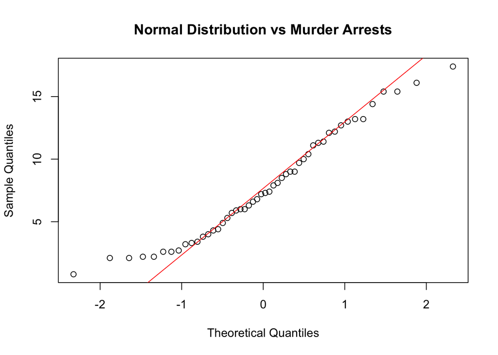

```r
qqnorm(Murders, main = "Normal Distribution vs Murder Arrests"); qqline(Murders, col=2)
```

### Assaults

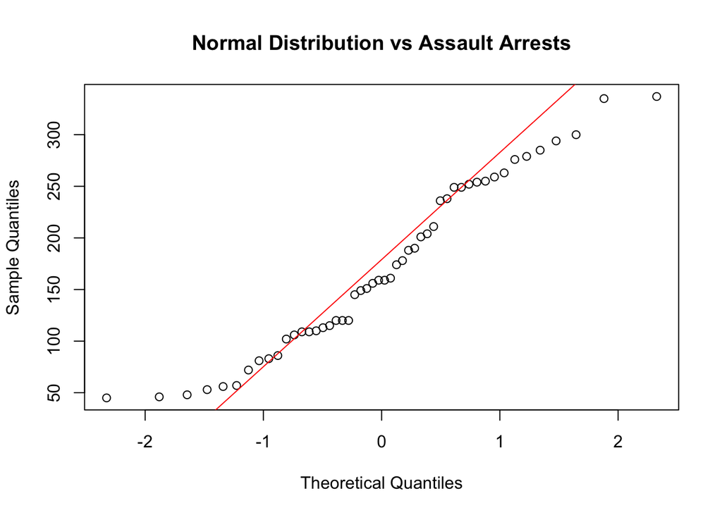

```r
qqnorm(Assaults, main = "Normal Distribution vs Assault Arrests"); qqline(Assaults, col=2)
```

## Creating a Map

```r
states <- readOGR("/Users/SebastianMartinez/Dropbox/0. Hertie/3/Collaborative Social Science Data Analysis/GitHub/repo1/analysis/Arrests/", "states")
states_df <- fortify(states)
```

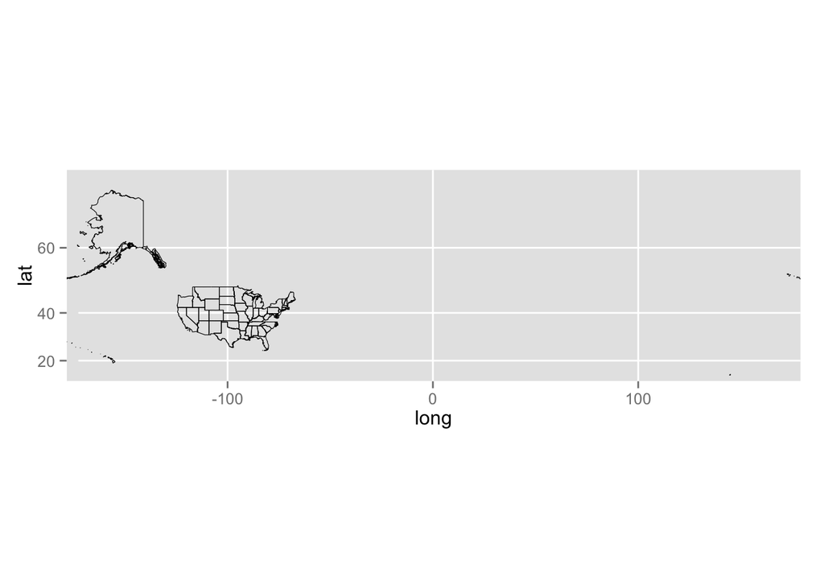

```r
map <- ggplot() + geom_path(data = states_df, aes(x = long, y = lat, group = group), color = 'black', fill = 'gray', size = .2)
map_projected <- map +  coord_map()
print(map_projected)
```

**Note:* The country looks small because the Mercartor Projection includes the western-most tip of Alaska in the right hand side of the map, where the Bering Strait is closest to Russia.

```r
source("poly_coords_function.r")
## load the shapefile
sport<- readShapePoly("s_16de14.shp")
##have a look at the attribute table headings
names(sport)
```

```
## [1] "STATE"  "NAME"   "FIPS"   "LON"    "LAT"    "Number"
```

```r
names(sport)<- c("ID", "name", "Partic_Per", "Pop_2001")
sport_geom<- poly_coords(sport)
## have a look at the sport_geom object to see its contents
head(sport_geom)
```

```
##   Poly_Name Order PolyCoordsY PolyCoordsX    name Partic_Per  Pop_2001
## 1        AL     1   -88.11011    30.25891 Alabama         01 -86.82676
## 2        AL     2   -88.10638    30.25751 Alabama         01 -86.82676
## 3        AL     3   -88.10419    30.25629 Alabama         01 -86.82676
## 4        AL     4   -88.10181    30.25531 Alabama         01 -86.82676
## 5        AL     5   -88.09912    30.25488 Alabama         01 -86.82676
## 6        AL     6   -88.09692    30.25513 Alabama         01 -86.82676
##         NA NA.1
## 1 32.79354    1
## 2 32.79354    1
## 3 32.79354    1
## 4 32.79354    1
## 5 32.79354    1
## 6 32.79354    1
```

[figure not shown]

```r
##Make the map of % sports participation in London boroughs. We will use the plot function.
map<- qplot(PolyCoordsY, PolyCoordsX, data=sport_geom, group=Poly_Name , fill= Partic_Per, geom="polygon")
map
```

```r
# The default colours are really nice but we may wish to produce the map in black and white:
# map + scale_fill_gradient(low="white", high="black")
```